# MLS Home Field Advantage R

```r
confint(model_team_interaction)
```

```
##                                            2.5 %       97.5 %
## (Intercept)                            1.0446000  1.710116952
## is_home                                0.3692003  1.289875822
## C(team)Chicago Fire FC                -1.2484108 -0.400423824
## C(team)Colorado Rapids                -1.0638439 -0.219608668
## C(team)Columbus Crew SC               -0.9364155 -0.100910206
## C(team)DC United                      -0.9489014 -0.104666140
## C(team)FC Cincinnati                  -1.3467092  0.003756876
## C(team)FC Dallas                      -0.8089127  0.031723833
## C(team)Houston Dynamo                 -1.1902807 -0.346045450
## C(team)LA Galaxy                      -0.7864408  0.054195743
## C(team)LAFC                           -0.3508261  0.713756226
## C(team)Minnesota United FC            -1.2054824 -0.255116892
## C(team)Montreal Impact                -0.8988004 -0.058163807
## C(team)New England Revolution         -1.0753382 -0.231102921
## C(team)New York City FC               -0.6281126  0.214304751
## C(team)New York Red Bulls             -0.6114937  0.222368088
## C(team)Orlando City SC                -0.9895873 -0.141600295
## C(team)Philadelphia Union             -0.9122035 -0.069786159
## C(team)Portland Timbers               -0.7615686  0.070681442
## C(team)Real Salt Lake                 -0.9774521 -0.136815493
## C(team)San Jose Earthquakes           -1.1143577 -0.268266281
## C(team)Seattle Sounders FC            -0.6871006  0.145149527
## C(team)Sporting Kansas City           -0.8412488 -0.002357114
## C(team)Toronto FC                     -0.6437517  0.190110023
## C(team)Vancouver Whitecaps            -0.7075221  0.136713171
## is_home:C(team)Chicago Fire FC        -0.3106138  0.871236674
## is_home:C(team)Colorado Rapids        -0.5448900  0.632940319
## is_home:C(team)Columbus Crew SC       -0.4253379  0.741178197
## is_home:C(team)DC United              -0.4699867  0.705266806
## is_home:C(team)FC Cincinnati          -1.7794505  0.120374414
## is_home:C(team)FC Dallas              -0.2698062  0.902864904
## is_home:C(team)Houston Dynamo         -0.2315429  0.944985081
## is_home:C(team)LA Galaxy              -0.6697801  0.505473445
## is_home:C(team)LAFC                   -0.9901981  0.483745202
## is_home:C(team)Minnesota United FC    -0.3705696  0.955837407
## is_home:C(team)Montreal Impact        -0.5169972  0.655673893
## is_home:C(team)New England Revolution -0.2615842  0.918938117
## is_home:C(team)New York City FC       -0.6863424  0.486357143
## is_home:C(team)New York Red Bulls     -0.4301684  0.735171179
## is_home:C(team)Orlando City SC        -0.8211422  0.362066051
## is_home:C(team)Philadelphia Union     -0.5490180  0.628842552
## is_home:C(team)Portland Timbers       -0.4765134  0.687673437
## is_home:C(team)Real Salt Lake         -0.3063551  0.868898474
## is_home:C(team)San Jose Earthquakes   -0.4947451  0.687105347
## is_home:C(team)Seattle Sounders FC    -0.3588721  0.799530046
## is_home:C(team)Sporting Kansas City   -0.4525564  0.721449649
## is_home:C(team)Toronto FC             -0.6045649  0.558391997
## is_home:C(team)Vancouver Whitecaps    -0.9756652  0.200862823
```

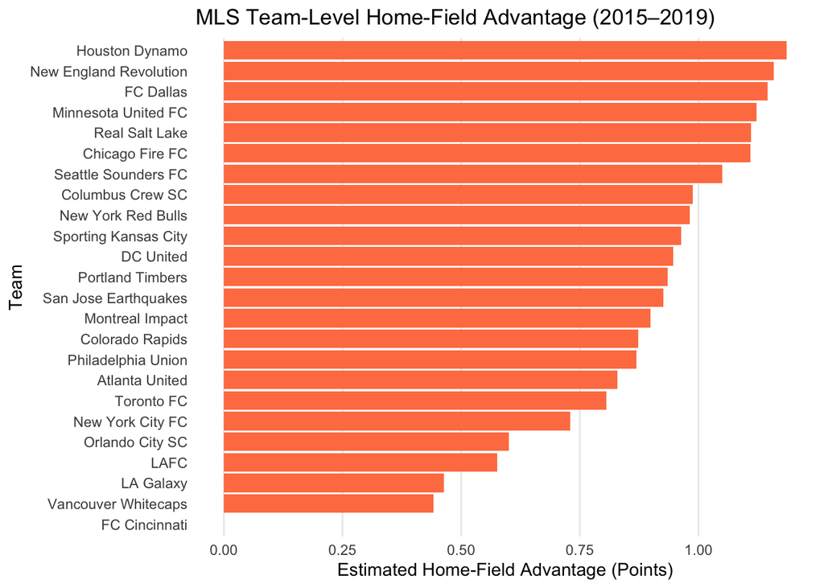

```r
library(tidyverse)

# Create the data
team_home_adv <- data.frame(
  team = c(
    "Atlanta United", "Chicago Fire FC", "Colorado Rapids", "Columbus Crew SC",
    "DC United", "FC Cincinnati", "FC Dallas", "Houston Dynamo", "LA Galaxy",
    "LAFC", "Minnesota United FC", "Montreal Impact", "New England Revolution",
    "New York City FC", "New York Red Bulls", "Orlando City SC",
    "Philadelphia Union", "Portland Timbers", "Real Salt Lake",
    "San Jose Earthquakes", "Seattle Sounders FC", "Sporting Kansas City",
    "Toronto FC", "Vancouver Whitecaps"
  ),
  home_effect = c(
    0.8295,
    0.8295 + 0.2803,
    0.8295 + 0.0440,
    0.8295 + 0.1579,
    0.8295 + 0.1176,
    0.8295 - 0.8295,
    0.8295 + 0.3165,
    0.8295 + 0.3567,
    0.8295 - 0.3661,
    0.8295 - 0.2532,
    0.8295 + 0.2926,
    0.8295 + 0.0693,
    0.8295 + 0.3287,
    0.8295 - 0.1000,
    0.8295 + 0.1525,
    0.8295 - 0.2295,
    0.8295 + 0.0399,
    0.8295 + 0.1056,
    0.8295 + 0.2813,
    0.8295 + 0.0962,
    0.8295 + 0.2203,
    0.8295 + 0.1344,
    0.8295 - 0.0231,
    0.8295 - 0.3874
  )
)

# Sort by estimated home-field advantage
team_home_adv <- team_home_adv |>
  arrange(home_effect)

# Plot
ggplot(team_home_adv, aes(x = home_effect, y = reorder(team, home_effect))) +
  geom_col(fill = "coral") +
  labs(
    title = "MLS Team-Level Home-Field Advantage (2015–2019)",
    x = "Estimated Home-Field Advantage (Points)",
    y = "Team"
  ) +
  theme_minimal() +
  theme(
    panel.grid.major.y = element_blank(),
    panel.grid.minor = element_blank()
  )
```

## Team-Level Home-Field Advantage in MLS

We extended our regression to estimate **home-field advantage for each team**, with **Atlanta United as the baseline**. The `is_home` coefficient represents the home advantage for Atlanta, and the interaction terms (`is_home:C(team)`) show how other teams differ from Atlanta.

To calculate each team’s estimated home-field advantage (in points per match), we **add the baseline `is_home` coefficient (0.83) to the team’s interaction coefficient**.

## **Conclusions**

The main takeaway is that there is a clear home-field advantage in MLS. While our last two regressions didn’t produce statistically significant results for every season or team, we consistently observed a general advantage for home teams across the five seasons analyzed. Even though the year- and team-level estimates are somewhat noisy, they still provide useful hints about real trends and shouldn’t be dismissed entirely.

#### **P.S.**

I also replicated this analysis in R to highlight my proficiency in that language, showing that I can work seamlessly across multiple tools in analytics.